# Multimodal model Scope:

The scope of this notebook is to create the classification model to classify the tumors in three classes (response, non-response and stable). We will use elastography images as input to the first channel of the multimodal and for the second channel tabular data with information on perfused area and cell line type. The goal is to find how strong is the relation between the three classes and the tumor characteristics. In other words to identify which features/attributes (elastic modulus, perfused area, cell line, therapy, stresses) contributed the most to the prediction of the class.

```
Found 1365 images belonging to 3 classes.
```

## Shear Wave Elastography (SWE) images

#### Here we show the image data that we will use in our multimoodal, alongside their label (Response, Stable, non-Response)

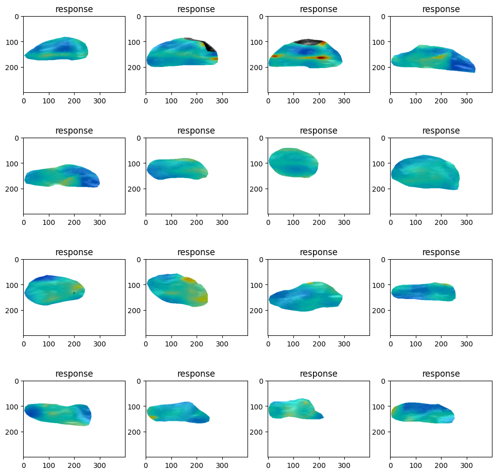

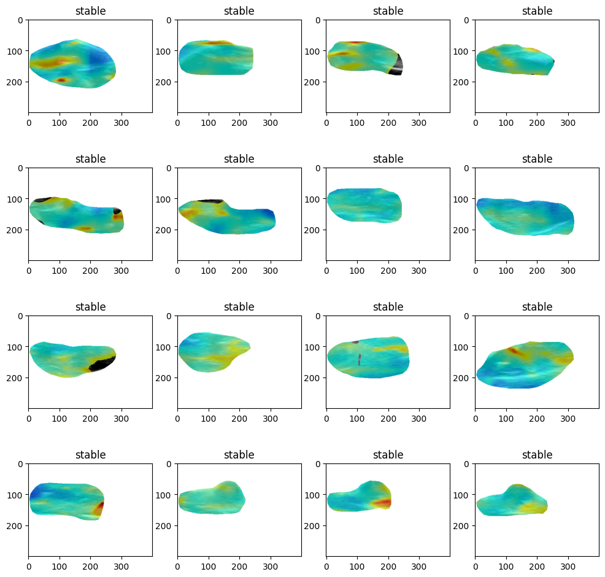

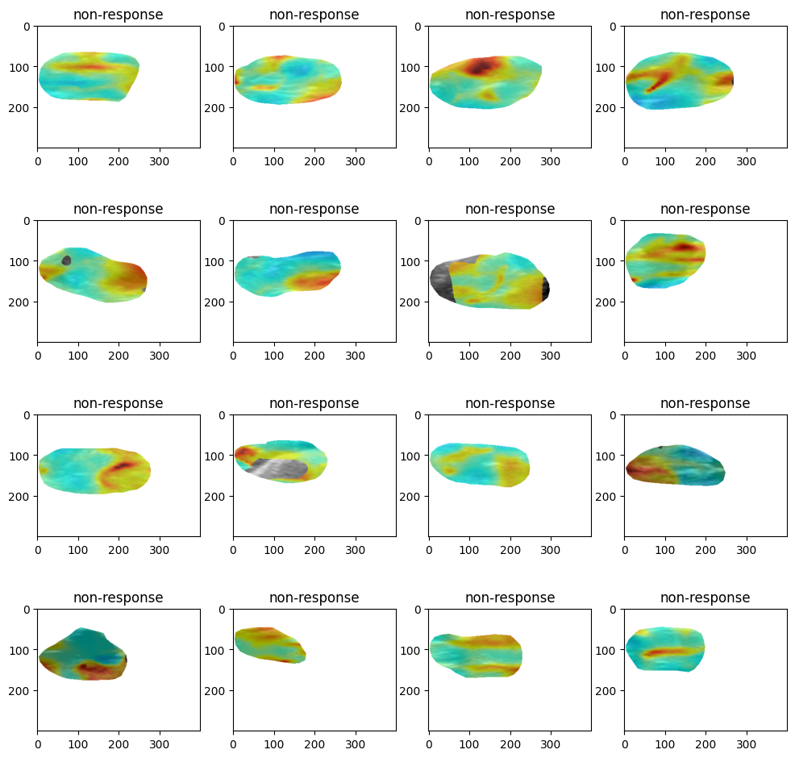

```
Found 1365 images belonging to 3 classes.
```

```
We have 1365 total observations
```

## Tabular Data. Information on average elastic modulus, perfused area and cell line

|  | name | response | swe | area | Cell lines | cancer |
| --- | --- | --- | --- | --- | --- | --- |
| 0 | 4T1 LOOK DAY29_1C1_1A_b_cropped_square.tif | 1 | 34.641412 | 0.624986 | 4T1 | Breast |
| 1 | 4T1 LOOK DAY29_1C1_1A_c_cropped_square.tif | 1 | 23.514638 | 0.624986 | 4T1 | Breast |
| 2 | 4T1 LOOK DAY29_1C1_1A_cropped_square.tif | 1 | 20.450058 | 0.624986 | 4T1 | Breast |
| 3 | 4T1 LOOK DAY29_1C1_1D_c_cropped_square.tif | 1 | 29.826093 | 0.793898 | 4T1 | Breast |
| 4 | 4T1 LOOK DAY29_1C1_1D_cropped_square.tif | 1 | 22.371027 | 0.793898 | 4T1 | Breast |

|  | response | swe | area |
| --- | --- | --- | --- |
| count | 1365.000000 | 1365.000000 | 1157.000000 |
| mean | 1.956044 | 39.719810 | 0.569521 |
| std | 0.830752 | 12.949924 | 0.168682 |
| min | 1.000000 | 15.000710 | 0.255284 |
| 25% | 1.000000 | 28.774137 | 0.426063 |
| 50% | 2.000000 | 39.517520 | 0.547296 |
| 75% | 3.000000 | 49.791293 | 0.708252 |
| max | 3.000000 | 63.485778 | 0.933730 |

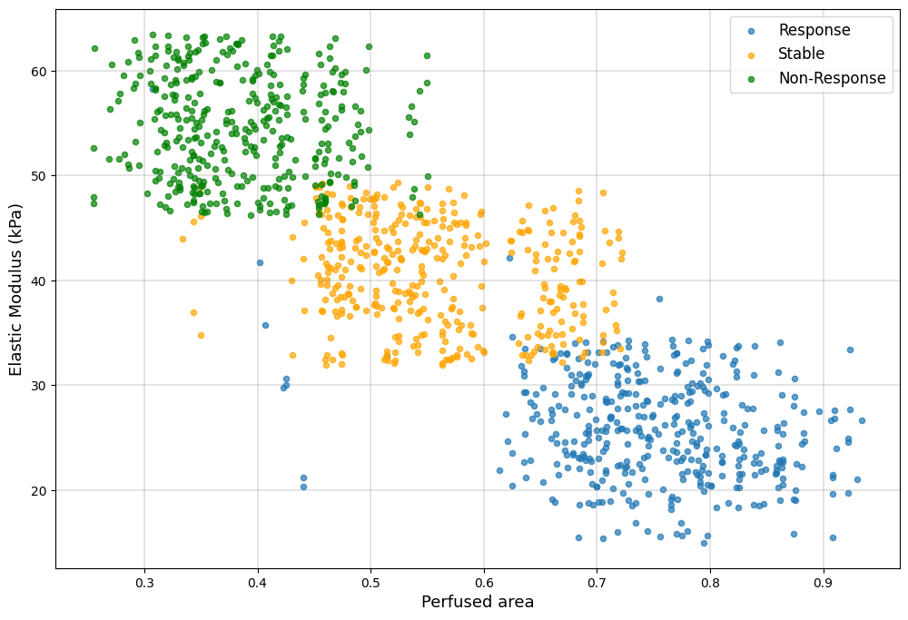

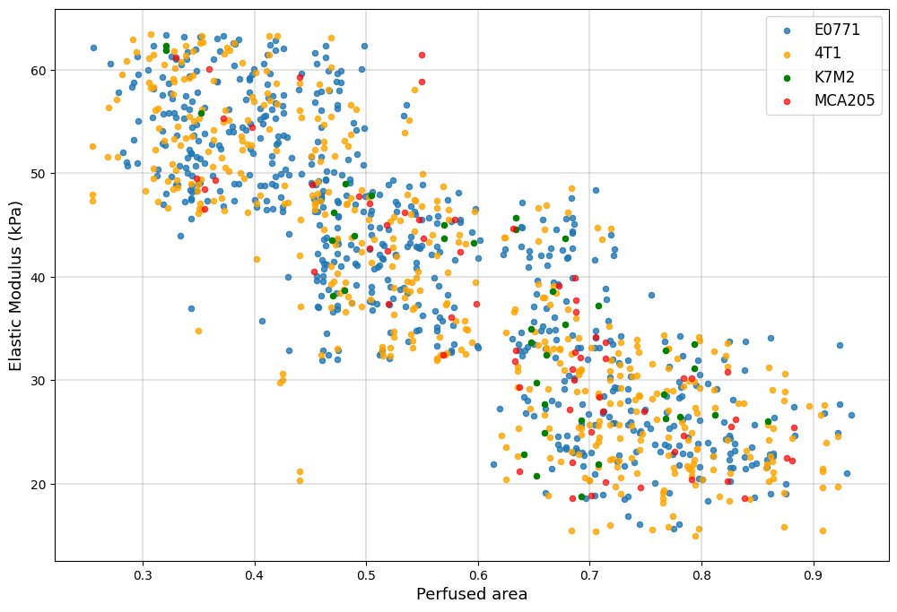

```
E0771     703
4T1       547
MCA205     76
K7M2       39
Name: Cell lines, dtype: int64
```

```
Breast     1250
Sarcoma     115
Name: cancer, dtype: int64
```

#### Next two figures are the three clusters again seperated for each cancer line and cancer respectively

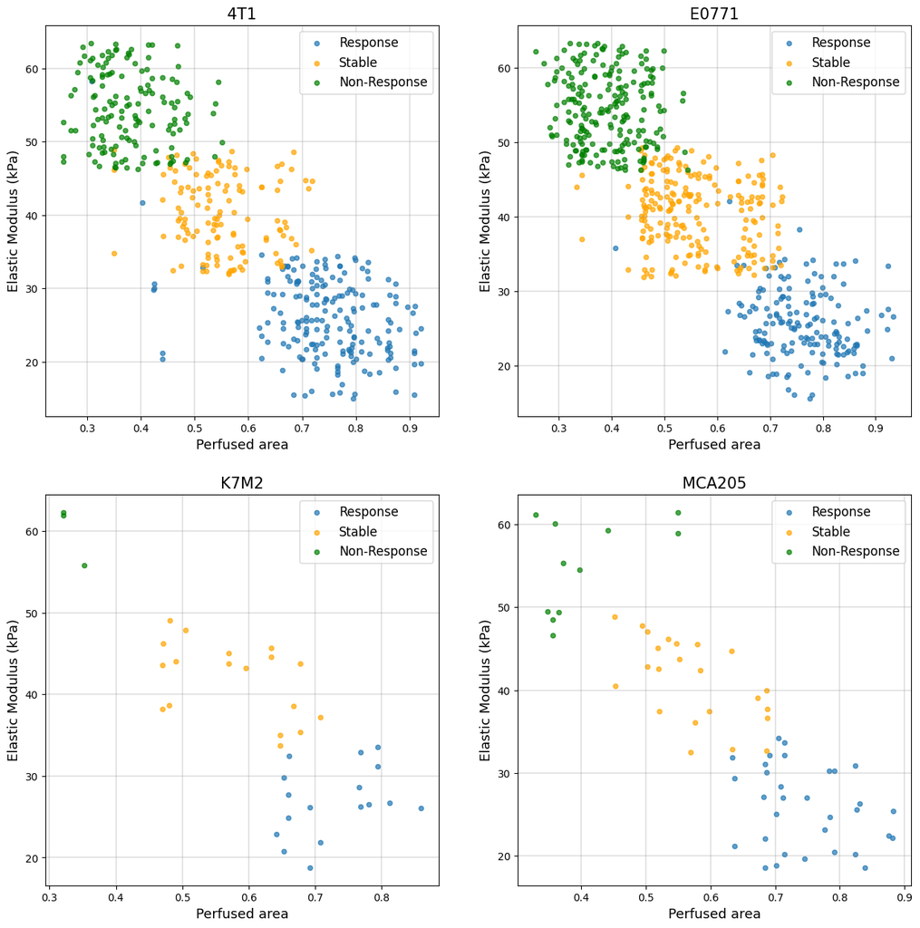

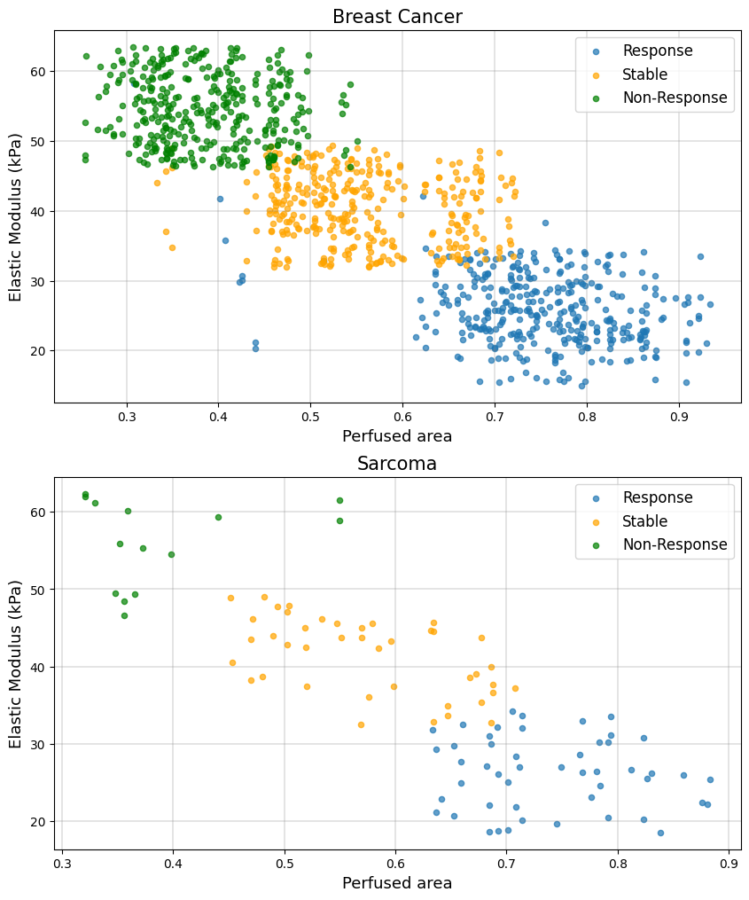

### It seems that by using both the Elastic Modulus and the Perfused Area of the tumor, our data are already well classified into Response, Stable and non-Response

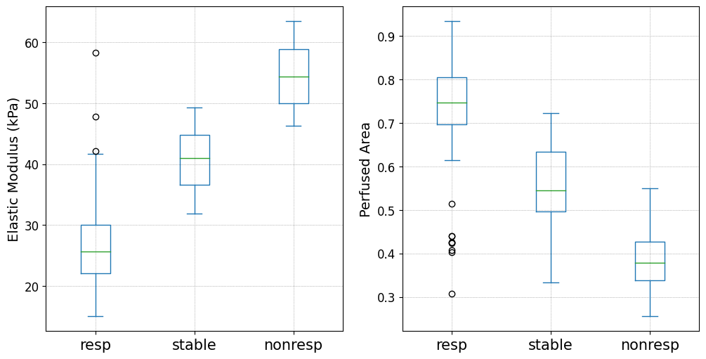

## Shallow Machine Leaning models to assess prediction accuracy of classification models using only the tabular data.

```
array([[34.64141156,  0.62498627,  1.        ,  0.        ,  0.        ,
         0.        ],
       [23.51463809,  0.62498627,  1.        ,  0.        ,  0.        ,
         0.        ]])
```

```
array([[-0.41630225,  0.32895552,  1.        ,  0.        ,  0.        ,
         0.        ],
       [-1.29048301,  0.32895552,  1.        ,  0.        ,  0.        ,
         0.        ]])
```

```
Train set: (925, 6) (925,)
Test set: (232, 6) (232,)
```

#### Logistic Regression

```
Probability of belonging to the three classes of the first two data in the test set: [[1.14998380e-07 6.82080448e-03 9.93179081e-01]
 [9.72403568e-01 2.75964217e-02 1.04920003e-08]]

Accuracy score: 0.9568965517241379
```

#### XG Boost

```
Accuracy score: 0.9698275862068966
```

### XG Boost model interpretability

As expected elastic modulus and normalized perfused area are the most important features for the predictions. K7M2 and MCA205 has no significant value on predicting the class which makes sense considering their limited number of observations, especially in the test set.

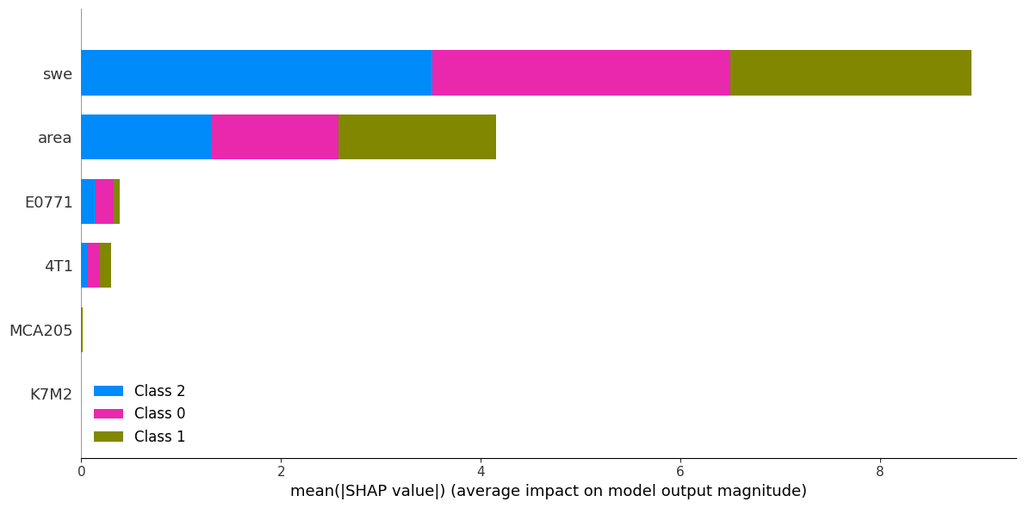

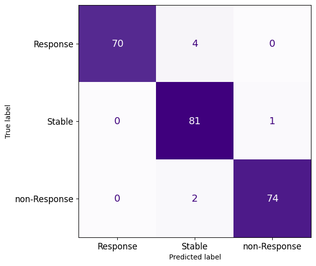

```
Training set has total 955 observations
Validation set has total 205 observations
Test set has total 205 observations


Ratio of obervations with response label to total number of observations in the validation dataset is  0.35121951219512193
Ratio of obervations with stable label to total number of observations in the validation dataset is  0.33170731707317075
Ratio of obervations with non-response label to total number of observations in the validation dataset is  0.3170731707317073


Ratio of obervations with response label to total number of observations in the test dataset is  0.33658536585365856
Ratio of obervations with stable label to total number of observations in the test dataset is  0.33170731707317075
Ratio of obervations with non-response label to total number of observations in the test dataset is  0.33170731707317075

Ratio of obervations with response label to total number of observations in the validation dataset is  0.35121951219512193
Ratio of obervations with stable label to total number of observations in the validation dataset is  0.33170731707317075
Ratio of obervations with non-response label to total number of observations in the validation dataset is  0.3170731707317073


Ratio of obervations with response label to total number of observations in the validation dataset is  0.33658536585365856
Ratio of obervations with stable label to total number of observations in the validation dataset is  0.33170731707317075
Ratio of obervations with non-response label to total number of observations in the validation dataset is  0.33170731707317075
```

```
Model: "model_11"
_________________________________________________________________
 Layer (type)                Output Shape              Param #
=================================================================
 tabular (InputLayer)        [(None, 6)]               0

 dense_44 (Dense)            (None, 32)                224

 dropout_34 (Dropout)        (None, 32)                0

 dense_45 (Dense)            (None, 16)                528

 dropout_35 (Dropout)        (None, 16)                0

 dense_46 (Dense)            (None, 8)                 136

 dense_47 (Dense)            (None, 3)                 27

=================================================================
Total params: 915
Trainable params: 915
Non-trainable params: 0
_________________________________________________________________
```

```
Loss on test set: 0.17
Accuracy on test set: 0.94
```

### Convolutional Neural Network (CNN) model

#### Having as input just the SWE elastography images. This will be compared later on with the multimodal which will have extra tabular information.

```
Model: "model_8"
_________________________________________________________________
 Layer (type)                Output Shape              Param #
=================================================================
 input_10 (InputLayer)       [(None, 60, 80, 3)]       0

 conv2d_30 (Conv2D)          (None, 60, 80, 16)        2368

 activation_30 (Activation)  (None, 60, 80, 16)        0

 max_pooling2d_30 (MaxPoolin  (None, 30, 40, 16)       0
 g2D)

 dropout_30 (Dropout)        (None, 30, 40, 16)        0

 conv2d_31 (Conv2D)          (None, 30, 40, 16)        6416

 activation_31 (Activation)  (None, 30, 40, 16)        0

 max_pooling2d_31 (MaxPoolin  (None, 15, 20, 16)       0
 g2D)

 dropout_31 (Dropout)        (None, 15, 20, 16)        0

 conv2d_32 (Conv2D)          (None, 15, 20, 8)         1160

 activation_32 (Activation)  (None, 15, 20, 8)         0

 max_pooling2d_32 (MaxPoolin  (None, 7, 10, 8)         0
 g2D)

 dropout_32 (Dropout)        (None, 7, 10, 8)          0

 flatten_9 (Flatten)         (None, 560)               0

 dense_8 (Dense)             (None, 3)                 1683

=================================================================
Total params: 11,627
Trainable params: 11,627
Non-trainable params: 0
_________________________________________________________________
```

```
Loss on test set: 0.62
Accuracy on test set: 0.69
```

```
Loss on test set: 0.32
Accuracy on test set: 0.86
```

#### XG Boost

##### The input now is just an average value of elastic modulus for each input in tabular

```
Train set: (1092, 1) (1092,)
Test set: (273, 1) (273,)
```

```
Accuracy score: 0.8937728937728938
```

## Multimodal

#### First input: SWE images (CNN)

#### Second input: Tabular data of perfused area and cell line (RNN)

#### CNN and RNN outputs are then concatenated

```
Train set: (925, 5) (925,)
Test set: (232, 5) (232,)
```

```
Model: "model_12"
__________________________________________________________________________________________________
 Layer (type)                   Output Shape         Param #     Connected to
==================================================================================================
 input_17 (InputLayer)          [(None, 60, 80, 3)]  0           []

 conv2d_48 (Conv2D)             (None, 60, 80, 16)   2368        ['input_17[0][0]']

 conv2d_49 (Conv2D)             (None, 60, 80, 16)   6416        ['conv2d_48[0][0]']

 activation_45 (Activation)     (None, 60, 80, 16)   0           ['conv2d_49[0][0]']

 conv2d_50 (Conv2D)             (None, 60, 80, 16)   2320        ['activation_45[0][0]']

 activation_46 (Activation)     (None, 60, 80, 16)   0           ['conv2d_50[0][0]']

 max_pooling2d_42 (MaxPooling2D  (None, 30, 40, 16)  0           ['activation_46[0][0]']
 )

 dropout_51 (Dropout)           (None, 30, 40, 16)   0           ['max_pooling2d_42[0][0]']

 conv2d_51 (Conv2D)             (None, 30, 40, 32)   4640        ['dropout_51[0][0]']

 activation_47 (Activation)     (None, 30, 40, 32)   0           ['conv2d_51[0][0]']

 max_pooling2d_43 (MaxPooling2D  (None, 15, 20, 32)  0           ['activation_47[0][0]']
 )

 dropout_52 (Dropout)           (None, 15, 20, 32)   0           ['max_pooling2d_43[0][0]']

 conv2d_52 (Conv2D)             (None, 15, 20, 64)   18496       ['dropout_52[0][0]']

 activation_48 (Activation)     (None, 15, 20, 64)   0           ['conv2d_52[0][0]']

 max_pooling2d_44 (MaxPooling2D  (None, 7, 10, 64)   0           ['activation_48[0][0]']
 )

 dropout_53 (Dropout)           (None, 7, 10, 64)    0           ['max_pooling2d_44[0][0]']

 flatten_13 (Flatten)           (None, 4480)         0           ['dropout_53[0][0]']
```

[output cut: 45 more lines]

```
 ConcatG (Concatenate)          (None, 32)           0           ['g3[0][0]',
                                                                  'g1[0][0]']

 dense_43 (Dense)               (None, 8)            136         ['dropout_56[0][0]']

 concatenate_3 (Concatenate)    (None, 40)           0           ['ConcatG[0][0]',
                                                                  'dense_43[0][0]']

 dense_44 (Dense)               (None, 3)            123         ['concatenate_3[0][0]']

==================================================================================================
Total params: 323,619
Trainable params: 323,619
Non-trainable params: 0
__________________________________________________________________________________________________
```

```
Loss on test set: 0.18
Accuracy on test set: 0.94
```